# Health Care Project-1

## Project Task: Week 1

**Importing libries for initial data sheet analysis

```python
import pandas as pd
```

Importing data sheet using Pandas

```python
data = pd.read_csv('health care diabetes.csv')
```

```python
data.head(10)
```

|  | Pregnancies | Glucose | BloodPressure | SkinThickness | Insulin | BMI | DiabetesPedigreeFunction | Age | Outcome |
| --- | --- | --- | --- | --- | --- | --- | --- | --- | --- |
| 0 | 6 | 148 | 72 | 35 | 0 | 33.6 | 0.627 | 50 | 1 |
| 1 | 1 | 85 | 66 | 29 | 0 | 26.6 | 0.351 | 31 | 0 |
| 2 | 8 | 183 | 64 | 0 | 0 | 23.3 | 0.672 | 32 | 1 |
| 3 | 1 | 89 | 66 | 23 | 94 | 28.1 | 0.167 | 21 | 0 |
| 4 | 0 | 137 | 40 | 35 | 168 | 43.1 | 2.288 | 33 | 1 |
| 5 | 5 | 116 | 74 | 0 | 0 | 25.6 | 0.201 | 30 | 0 |
| 6 | 3 | 78 | 50 | 32 | 88 | 31.0 | 0.248 | 26 | 1 |
| 7 | 10 | 115 | 0 | 0 | 0 | 35.3 | 0.134 | 29 | 0 |
| 8 | 2 | 197 | 70 | 45 | 543 | 30.5 | 0.158 | 53 | 1 |
| 9 | 8 | 125 | 96 | 0 | 0 | 0.0 | 0.232 | 54 | 1 |

## Project Task: Week 1

**i) Perform descriptive analysis. Understand the variables and their corresponding values. On the columns below, a value of zero does not make sense and thus indicates missing value:

• Glucose

• BloodPressure

• SkinThickness

• Insulin

• BMI **Check the missing value in the Dataframe by using isna() function

```python
data.isna().sum()
```

```
Pregnancies                 0
Glucose                     0
BloodPressure               0
SkinThickness               0
Insulin                     0
BMI                         0
DiabetesPedigreeFunction    0
Age                         0
Outcome                     0
dtype: int64
```

```python
data.describe().T
```

|  | count | mean | std | min | 25% | 50% | 75% | max |
| --- | --- | --- | --- | --- | --- | --- | --- | --- |
| Pregnancies | 768.0 | 3.845052 | 3.369578 | 0.000 | 1.00000 | 3.0000 | 6.00000 | 17.00 |
| Glucose | 768.0 | 120.894531 | 31.972618 | 0.000 | 99.00000 | 117.0000 | 140.25000 | 199.00 |
| BloodPressure | 768.0 | 69.105469 | 19.355807 | 0.000 | 62.00000 | 72.0000 | 80.00000 | 122.00 |
| SkinThickness | 768.0 | 20.536458 | 15.952218 | 0.000 | 0.00000 | 23.0000 | 32.00000 | 99.00 |
| Insulin | 768.0 | 79.799479 | 115.244002 | 0.000 | 0.00000 | 30.5000 | 127.25000 | 846.00 |
| BMI | 768.0 | 31.992578 | 7.884160 | 0.000 | 27.30000 | 32.0000 | 36.60000 | 67.10 |
| DiabetesPedigreeFunction | 768.0 | 0.471876 | 0.331329 | 0.078 | 0.24375 | 0.3725 | 0.62625 | 2.42 |
| Age | 768.0 | 33.240885 | 11.760232 | 21.000 | 24.00000 | 29.0000 | 41.00000 | 81.00 |
| Outcome | 768.0 | 0.348958 | 0.476951 | 0.000 | 0.00000 | 0.0000 | 1.00000 | 1.00 |

## Project Task: Week 1

**ii) Visually explore these variables using histograms. Treat the missing values accordingly, Check the data type of the imported data by using info() function and there is no missing value inthis data set

```python
data.info()
```

```
<class 'pandas.core.frame.DataFrame'>
RangeIndex: 768 entries, 0 to 767
Data columns (total 9 columns):
 #   Column                    Non-Null Count  Dtype
---  ------                    --------------  -----
 0   Pregnancies               768 non-null    int64
 1   Glucose                   768 non-null    int64
 2   BloodPressure             768 non-null    int64
 3   SkinThickness             768 non-null    int64
 4   Insulin                   768 non-null    int64
 5   BMI                       768 non-null    float64
 6   DiabetesPedigreeFunction  768 non-null    float64
 7   Age                       768 non-null    int64
 8   Outcome                   768 non-null    int64
dtypes: float64(2), int64(7)
memory usage: 54.1 KB
```

Importing graph plotting librray

```python
import matplotlib.pyplot as plt
import seaborn as sns; sns.set()
import numpy as np
```

## Project Task: Week 1

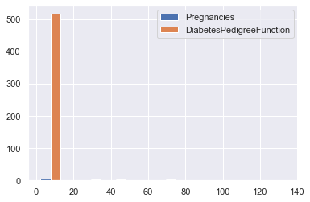

```python
Pregnancies_count = data["Pregnancies"].value_counts()
Glucose_count = data["Glucose"].value_counts()
BloodPressure_count = data["BloodPressure"].value_counts()
Insulin_count = data["Insulin"].value_counts()
BMI_count = data["BMI"].value_counts()
DiabetesPedigreeFunction_count = data["DiabetesPedigreeFunction"].value_counts()
Age_count = data["Age"].value_counts()
Outcome_count = data["Outcome"].value_counts()


plt.hist([Pregnancies_count,DiabetesPedigreeFunction_count],label=["Pregnancies","DiabetesPedigreeFunction"])
plt.legend(loc='upper right')
plt.show()
```

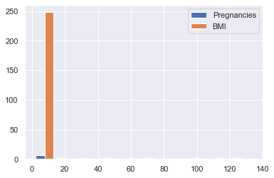

```python
plt.hist([Pregnancies_count,BMI_count],label=["Pregnancies","BMI"])
plt.legend(loc='upper right')
plt.show()
```

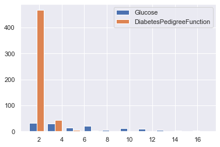

```python
plt.hist([Glucose_count,DiabetesPedigreeFunction_count],label=["Glucose","DiabetesPedigreeFunction"])
plt.legend(loc='upper right')
plt.show()
```

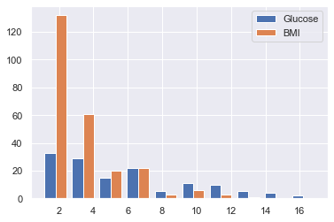

```python
plt.hist([Glucose_count,BMI_count],label=["Glucose","BMI"])
plt.legend(loc='upper right')
plt.show()
```

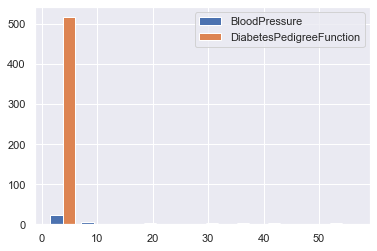

```python
plt.hist([BloodPressure_count,DiabetesPedigreeFunction_count],label=["BloodPressure","DiabetesPedigreeFunction"])
plt.legend(loc='upper right')
plt.show()
```

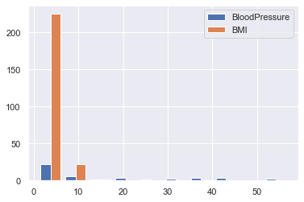

```python
plt.hist([BloodPressure_count,BMI_count],label=["BloodPressure","BMI"])
plt.legend(loc='upper right')
plt.show()
```

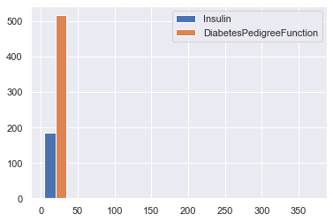

```python
plt.hist([Insulin_count,DiabetesPedigreeFunction_count],label=["Insulin","DiabetesPedigreeFunction"])
plt.legend(loc='upper right')
plt.show()
```

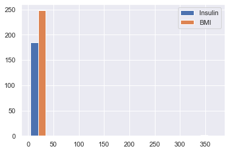

```python
plt.hist([Insulin_count,BMI_count],label=["Insulin","BMI"])
plt.legend(loc='upper right')
plt.show()
```

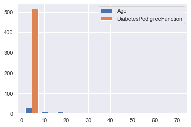

```python
plt.hist([Age_count,DiabetesPedigreeFunction_count],label=["Age","DiabetesPedigreeFunction"])
plt.legend(loc='upper right')
plt.show()
```

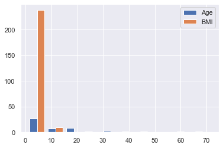

```python
plt.hist([Age_count,BMI_count],label=["Age","BMI"])
plt.legend(loc='upper right')
plt.show()
```

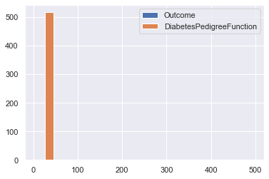

```python
plt.hist([Outcome_count,DiabetesPedigreeFunction_count],label=["Outcome","DiabetesPedigreeFunction"])
plt.legend(loc='upper right')
plt.show()
```

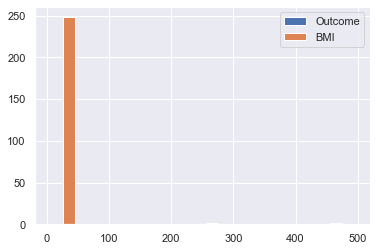

```python
plt.hist([Outcome_count,BMI_count],label=["Outcome","BMI"])
plt.legend(loc='upper right')
plt.show()
```

## Project Task: Week 2

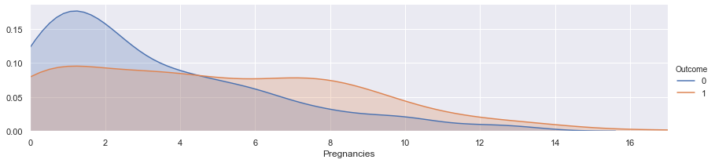

```python
facet = sns.FacetGrid(data, hue="Outcome",aspect=4)
facet.map(sns.kdeplot,'Pregnancies',shade= True)
facet.set(xlim=(0, data['Pregnancies'].max()))
facet.add_legend()
```

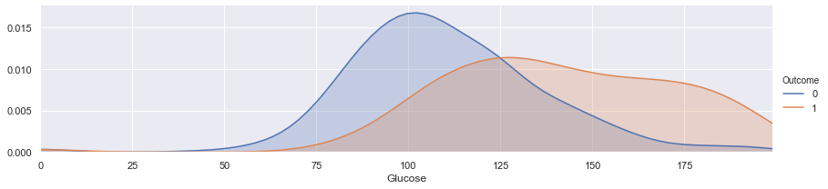

```python
facet = sns.FacetGrid(data, hue="Outcome",aspect=4)
facet.map(sns.kdeplot,'Glucose',shade= True)
facet.set(xlim=(0, data['Glucose'].max()))
facet.add_legend()
```

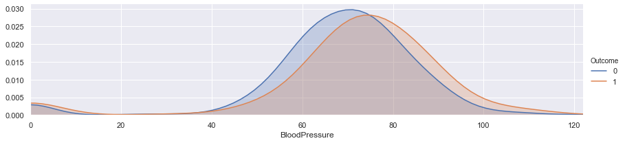

```python
facet = sns.FacetGrid(data,hue='Outcome',aspect=4)
facet.map(sns.kdeplot,'BloodPressure',shade=True)
facet.set(xlim=(0,data['BloodPressure'].max()))
facet.add_legend()
```

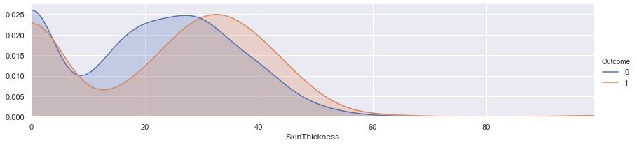

```python
facet = sns.FacetGrid(data,hue='Outcome',aspect=4)
facet.map(sns.kdeplot,'SkinThickness',shade=True)
facet.set(xlim=(0,data["SkinThickness"].max()))
facet.add_legend()
```

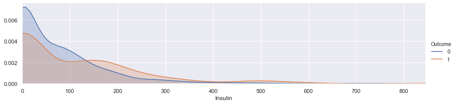

```python
facet = sns.FacetGrid(data,hue='Outcome',aspect=4)
facet.map(sns.kdeplot,'Insulin',shade=True)
facet.set(xlim=(0,data["Insulin"].max()))
facet.add_legend()
```

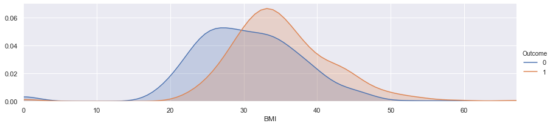

```python
facet = sns.FacetGrid(data,hue='Outcome',aspect=4)
facet.map(sns.kdeplot,'BMI',shade=True)
facet.set(xlim=(0,data["BMI"].max()))
facet.add_legend()
```

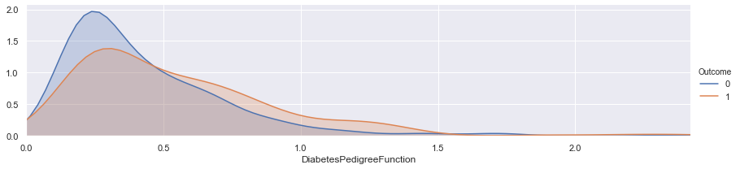

```python
facet = sns.FacetGrid(data,hue='Outcome',aspect=4)
facet.map(sns.kdeplot,'DiabetesPedigreeFunction',shade=True)
facet.set(xlim=(0,data["DiabetesPedigreeFunction"].max()))
facet.add_legend()
```

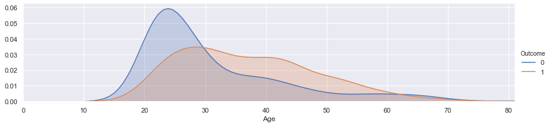

```python
facet = sns.FacetGrid(data,hue='Outcome',aspect=4)
facet.map(sns.kdeplot,'Age',shade=True)
facet.set(xlim=(0,data["Age"].max()))
facet.add_legend()
```

Project Task: Week 2 Create scatter charts between the pair of variables to understand the relationships. Describe your findings.

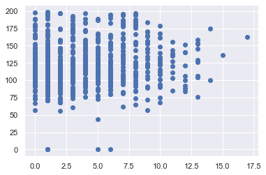

```python
plt.scatter(data["Pregnancies"],data["Glucose"])
plt.show()
```

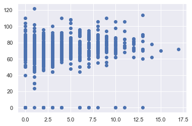

```python
plt.scatter(data["Pregnancies"],data["BloodPressure"])
plt.show()
```

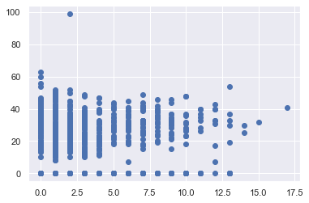

```python
plt.scatter(data["Pregnancies"],data["SkinThickness"])
plt.show()
```

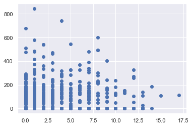

```python
plt.scatter(data["Pregnancies"],data["Insulin"])
plt.show()
```

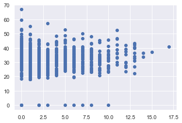

```python
plt.scatter(data["Pregnancies"],data["BMI"])
plt.show()
```

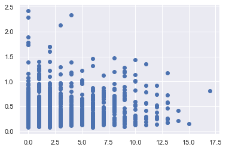

```python
plt.scatter(data["Pregnancies"],data["DiabetesPedigreeFunction"])
plt.show()
```

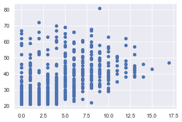

```python
plt.scatter(data["Pregnancies"],data["Age"])
plt.show()
```

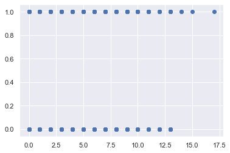

```python
plt.scatter(data["Pregnancies"],data["Outcome"])
plt.show()
```

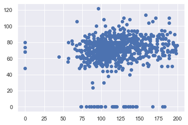

```python
plt.scatter(data["Glucose"],data["BloodPressure"])
plt.show()
```

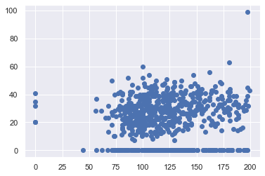

```python
plt.scatter(data["Glucose"],data["SkinThickness"])
plt.show()
```

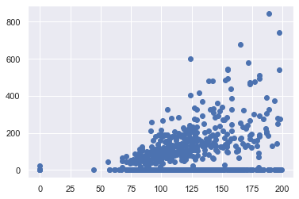

```python
plt.scatter(data["Glucose"],data["Insulin"])
plt.show()
```

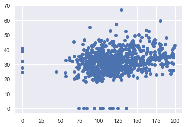

```python
plt.scatter(data["Glucose"],data["BMI"])
plt.show()
```

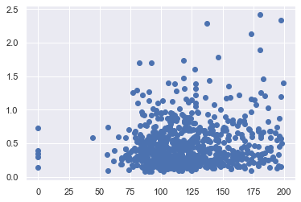

```python
plt.scatter(data["Glucose"],data["DiabetesPedigreeFunction"])
plt.show()
```

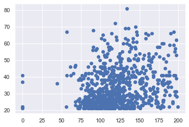

```python
plt.scatter(data["Glucose"],data["Age"])
plt.show()
```

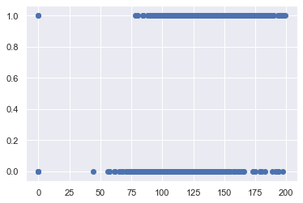

```python
plt.scatter(data["Glucose"],data["Outcome"])
plt.show()
```

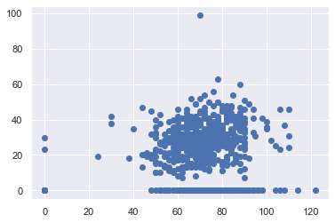

```python
plt.scatter(data["BloodPressure"],data["SkinThickness"])
plt.show()
```

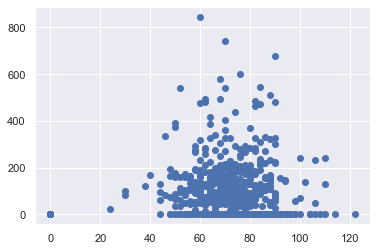

```python
plt.scatter(data["BloodPressure"],data["Insulin"])
plt.show()
```

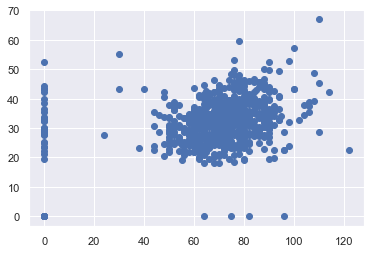

```python
plt.scatter(data["BloodPressure"],data["BMI"])
plt.show()
```

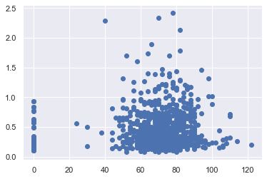

```python
plt.scatter(data["BloodPressure"],data["DiabetesPedigreeFunction"])
plt.show()
```

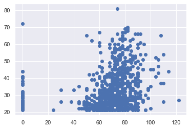

```python
plt.scatter(data["BloodPressure"],data["Age"])
plt.show()
```

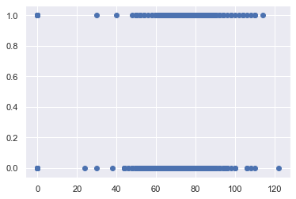

```python
plt.scatter(data["BloodPressure"],data["Outcome"])
plt.show()
```

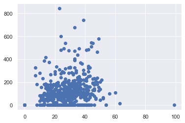

```python
plt.scatter(data["SkinThickness"],data["Insulin"])
plt.show()
```

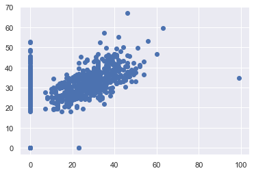

```python
plt.scatter(data["SkinThickness"],data["BMI"])
plt.show()
```

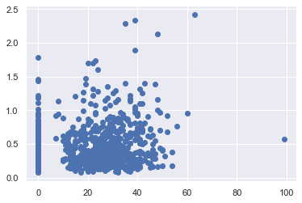

```python
plt.scatter(data["SkinThickness"],data["DiabetesPedigreeFunction"])
plt.show()
```

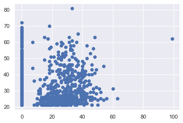

```python
plt.scatter(data["SkinThickness"],data["Age"])
plt.show()
```

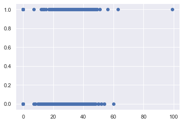

```python
plt.scatter(data["SkinThickness"],data["Outcome"])
plt.show()
```

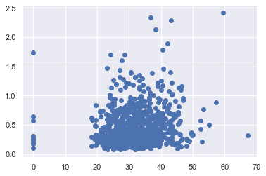

```python
plt.scatter(data["BMI"],data["DiabetesPedigreeFunction"])
plt.show()
```

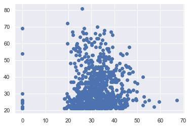

```python
plt.scatter(data["BMI"],data["Age"])
plt.show()
```

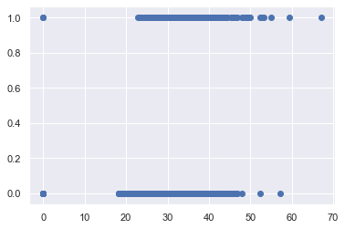

```python
plt.scatter(data["BMI"],data["Outcome"])
plt.show()
```

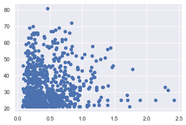

```python
plt.scatter(data["DiabetesPedigreeFunction"],data["Age"])
plt.show()
```

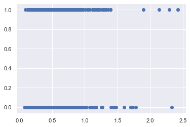

```python
plt.scatter(data["DiabetesPedigreeFunction"],data["Outcome"])
plt.show()
```

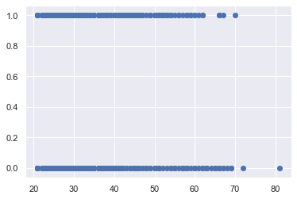

```python
plt.scatter(data["Age"],data["Outcome"])
plt.show()
```

## Project Task: Week 2

**iii) Perform correlation analysis. Visually explore it using a heat map.

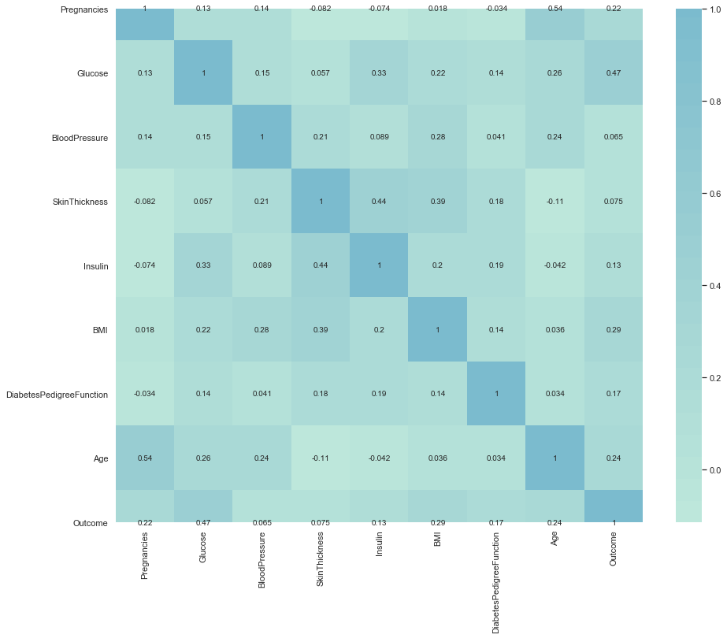

```python
plt.subplots(figsize=(15, 12))
corr = data.corr()
sns.heatmap(corr, annot=True, fmt=".2g",center=6)
plt.show()
```

## Project Task: Week 3

**1) Devise strategies for model building. It is important to decide the right validation framework. Express your thought process

```python
from sklearn.model_selection import train_test_split
from sklearn.metrics import accuracy_score
from sklearn.svm import SVC
from sklearn.linear_model import LogisticRegression
```

```python
X = data.drop(["Outcome"],axis=1)
Y = data["Outcome"]
```

```python
X.isna().sum()
```

```
Pregnancies                 0
Glucose                     0
BloodPressure               0
SkinThickness               0
Insulin                     0
BMI                         0
DiabetesPedigreeFunction    0
Age                         0
dtype: int64
```

```python
X_train,X_test,Y_train,Y_test = train_test_split(X,Y)
```

```python
model = SVC(kernel='linear',C=0.005958,gamma='auto').fit(X_train,Y_train)
```

```python
predict = model.predict(X_test)
```

```python
accuracy_score(Y_test,predict)
```

```
0.7447916666666666
```

```python
model1 = LogisticRegression(C=0.0005,max_iter=50000,n_jobs=5).fit(X_train,Y_train)
```

```python
predict_1 = model1.predict(X_test)
```

```python
accuracy_score(Y_test,predict_1)
```

```
0.7604166666666666
```

```python
from sklearn.tree import DecisionTreeClassifier
```

```python
model_2 = DecisionTreeClassifier(max_depth=5,ccp_alpha=0.00575).fit(X_train,Y_train)
```

```python
predict_2 = model_2.predict(X_test)
```

```python
accuracy_score(Y_test,predict_2)
```

```
0.7239583333333334
```

```python
from sklearn.ensemble import RandomForestClassifier
```

```python
model_3 = RandomForestClassifier(n_estimators=20000).fit(X_train,Y_train)
```

```python
predict_3 = model_3.predict(X_test)
```

```python
accuracy_score(Y_test,predict_3)
```

```
0.7760416666666666
```

```python
from sklearn.naive_bayes import GaussianNB
```

```python
model_4 = GaussianNB().fit(X_train,Y_train)
```

```python
predict_4 = model_4.predict(X_test)
```

```python
accuracy_score(Y_test,predict_4)
```

```
0.7291666666666666
```

```python
from xgboost import XGBClassifier
```

```python
model_5 = XGBClassifier(n_estimators=10000,learning_rate=0.007).fit(X_train,Y_train)
```

```python
predict_5 = model_5.predict(X_test)
```

```python
accuracy_score(Y_test,predict_5)
```

```
0.7447916666666666
```

## Project Task: Week 3

**2) Apply an appropriate classification algorithm to build a model. Compare various models with the results from KNN algorithm.

```python
from sklearn.neighbors import KNeighborsClassifier
```

```python
knn_model = KNeighborsClassifier().fit(X_train,Y_train)
```

```python
Knn_predict = knn_model.predict(X_test)
```

```python
accuracy_score(Y_test,Knn_predict)
```

```
0.7083333333333334
```

## Project Task: Week 4

**1)Data Modeling: Create a classification report by analyzing sensitivity, specificity, AUC (ROC curve), etc. Please be descriptive to explain what values of these parameter you have used.

```python
from sklearn.metrics import confusion_matrix
```

```python
cm = confusion_matrix(Y_test,knn_model.predict(X_test))
cm
```

```
array([[97, 17],
       [39, 39]], dtype=int64)
```

```python
from sklearn.metrics import classification_report
```

```python
print(classification_report(Y_test,model.predict(X_test)))
```

```
              precision    recall  f1-score   support

           0       0.74      0.89      0.80       114
           1       0.76      0.54      0.63        78

    accuracy                           0.74       192
   macro avg       0.75      0.71      0.72       192
weighted avg       0.75      0.74      0.73       192
```

```python
from sklearn.metrics import roc_curve
from sklearn.metrics import roc_auc_score
```

```python
probab = knn_model.predict_proba(X_test)
prob = probab[:,1]
auc = roc_auc_score(Y_test, prob)
print(auc)
```

```
0.7642825011246064
```

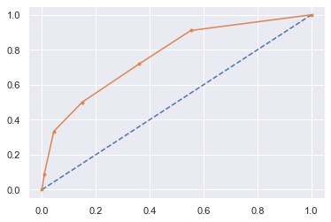

```python
fpr, tpr, thresholds = roc_curve(Y_test, prob)
plt.plot([0, 1], [0, 1],linestyle='--')
plt.plot(fpr, tpr, marker='.')
```